# The power of the browser:

6<sup>th</sup> September 2022

## Introduction

This content was made as part of the University of Bath “Creating Accessible Online resources” bookdown away day 2022.

The aim is to:

- cover the how, why and pitfalls with embedded content
- introduce the Desmos graphing calculator.

## Why embed content?

## Why include “media”?

The benefits of the web (over a static document) are:

- access to up to date information
- adding external image/video sources without worrying about copyright
- **interactive** widgets can support the flow of learning, assessment for learning, exploration, etc

I’ll talk about the downsides later…

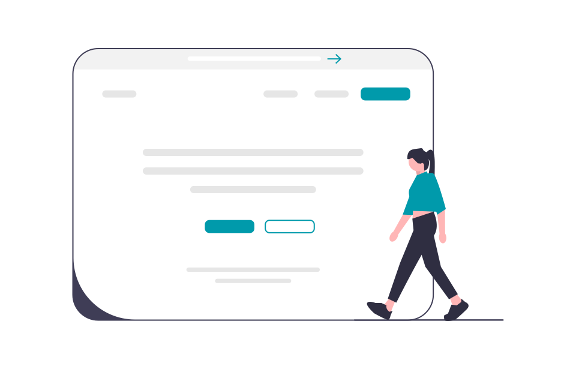

## How?

### Embedding content

## The gitbook format is a fully functioning website!

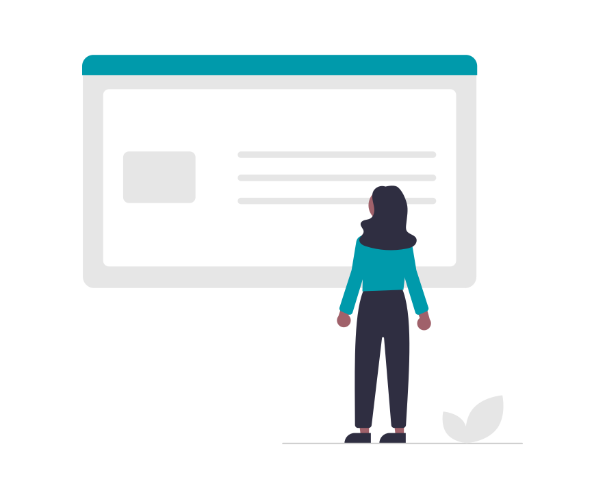

You can include:

- links
- image/video embeds
- webpage/webapp embeds (e.g. twitter feed, desmos graphical calculator)
- inline html, javascript, css with `<tags>`  
  (e.g. `<p>Markup you markdown!<\p>`)

## Adding links

### Links:

- are simple
- work in all formats (including PDF)
- give students control over accessing resource

### Accessibility tips for links:

- use descriptive links where possible (e.g. [Join the bookdown usergroup](https://teams.microsoft.com/l/team/19%3a796c455c3a5a4badbfbcb5434d869e98%40thread.tacv2/conversations?groupId=1485fec3-9ca3-443b-94ae-f8fb7d07bd98&tenantId=377e3d22-4ea1-422d-b0ad-8fcc89406b9e) instead of [https://teams.microsoft.com/l/team/19%3a…](https://teams.microsoft.com/l/team/19%3a796c455c3a5a4badbfbcb5434d869e98%40thread.tacv2/conversations?groupId=1485fec3-9ca3-443b-94ae-f8fb7d07bd98&tenantId=377e3d22-4ea1-422d-b0ad-8fcc89406b9e))
- don’t force users to open links in new tab/window

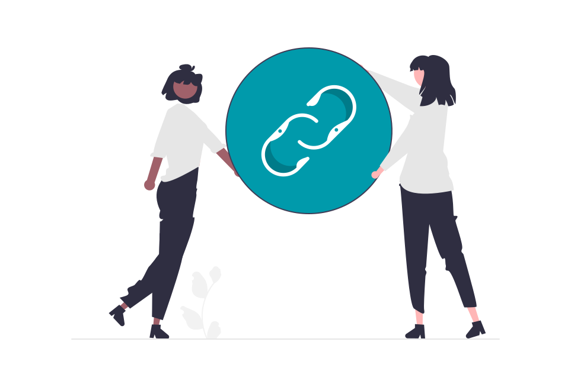

## Adding images from the web

[Educational Exceptions](https://teachinghub.bath.ac.uk/the-bath-blend/essentials/copyright/): you can use copyrighted images (e.g. figure from journal) in your lecture notes if:

1. it is for internal student use
2. it directly illustrates the content

It can be useful to point to an image on the web if you:

- host publicly (e.g. github)
- use cat .gifs to support learning!

[figure not shown]

## Adding videos

Copy and paste the embed code from *any* site - including Panopto!

[interactive chart not shown]

Note: this Panopto video has [quiz questions](https://teachinghub.bath.ac.uk/how-to-use-review-for-staff/#add_quiz) as you play through it!

## Embedding other web content

- [Desmos graphing calculator](https://www.desmos.com)
- [Xerte](https://teachinghub.bath.ac.uk/tools-and-resources/tel/xerte-online-toolkits/) (see quiz example)
- [Microsoft Forms](https://teachinghub.bath.ac.uk/microsoft-forms/) (general polls don’t show the results to student, but quiz allows you to give individuals instant feedback after all question have been submitted)
- [Mentimeter](https://teachinghub.bath.ac.uk/polling-with-mentimeter/) results slides (this is NOT for voting as audience paced voting slides don’t show the results)
- Twitter feed
- A webpage (*tread carefully*)

[interactive chart not shown]

## Desmos

### a simple & interactive graphing calculator

## Desmos graphing calculator

[interactive chart not shown]

*[View Damped Harmonic Oscillator](https://www.desmos.com/calculator/znlimgwkld)*

[interactive chart not shown]

*[View Travelling and standing wave plot](https://www.desmos.com/calculator/qy6jc8mfi9)*

## Desmos at a glance

### Why use Desmos?

- *Interactive* - students can play with parameters
- Fast to create (+ easy animation)
- [Digitally Accessible](https://help.desmos.com/hc/en-us/articles/4404860698253-What-Accessibility-features-does-Desmos-offer-)
- Free

### Plotting in desmos

- 2D Cartesian/polar coordinates
- Domain/range restrictions/piecewise functions,
- Shade area with inequalities, Differentiation, …
- Paste [tabular data](https://help.desmos.com/hc/en-us/articles/4405489674381-Tables) from clipboard (1000 points) and [fit](https://help.desmos.com/hc/en-us/articles/4406972958733-Regressions)

## Making plots in Desmos

1. Sign up for a free account on [Desmos](https://www.desmos.com)
2. Create graph ([see Graphing Calculator: Essential Skills](https://help.desmos.com/hc/en-us/articles/4405305421709-Graphing-Calculator-Essential-Skills))
3. Copy embed code

### Desmos Tips

- Add points on graph for quick sliders in the embed

## How to embed a Desmos graph

1. Get the embed code from Desmos
2. Paste in embed code to .Rmd file
3. Change some embed code parameters
   - `width="100%"`
   - `height="500px"` (even 600px is probably ok even for iphone)
4. Add a direct link (fallback for PDF and the *edit on desmos* button doesn’t display on mobile)

## Adding a Desmos embed as a figure

Same as a “normal” bookdown figure but instead of `knitr::include_graphics()` use `knitr::include_url(URL)`

### Example

[interactive chart not shown]

[View Travelling and standing wave plot](https://www.desmos.com/calculator/qy6jc8mfi9). Upper: two identical but counter-propogating travelling waves will result in a standing wave below.

## Desmos shortcomings

### What about my PDFs/offline support?

If there is no connection to the internet, the iframe will *not* load.

If you compile to a PDF, nothing is displayed, which is why a link is important! Possibly, one can do something clever in R to add use an image if knit to PDF…

## Take away messages

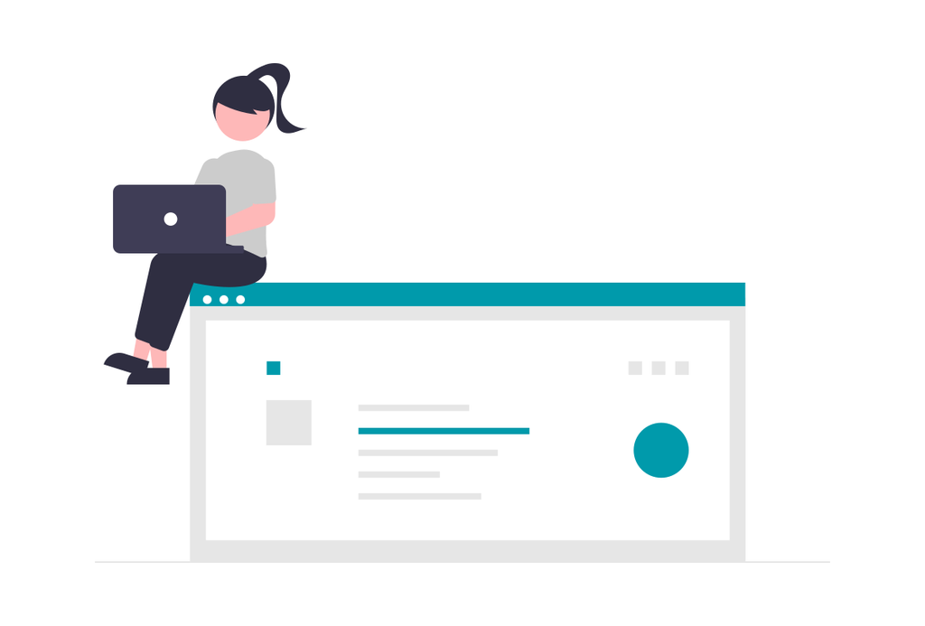

- It’s easy to embed web content with bookdown
- Embeds don’t work for offline/PDF use
- Desmos is free, interactive for students and easy to use: give it a try!

## Appendicies

## Embedding the whole Desmos calculator

This is **not** generally recommended:

- if you alter a parameter, you get an annoying “do you want to leave this page” when trying to read next page
- can be a squeeze on smaller screens

[interactive chart not shown]

## General tips for iframes and bookdown

- don’t have too many iframes per page (can be slow to load, take up resources)
- student interactions aren’t persistent and nothing gets saved: they get reloaded by a student every time they visit a page
- Consider mobile/tablet users where the screen sizes are smaller: sometimes a link is better?
- Avoid sites with advertising or a cookie requests that distracts from the content.
- there isn’t always much space, so pick simple things to embed (bookdown has comfortable margins)
- an iframe won’t display for students if they’re offline or viewing the PDF.

## iframes and accessibility pitfalls

There are no intrinsic accessibility issues with iframes.

*However*

- not all iframes work nicely on mobile browsers.
- the organization of the pages may not be clear to screen readers.
- navigation (via keyboard or due to increased zoom/limited size) can be challenging.

### Accessibility suggestions

- Test how it appears on your phone
- Pick shorter/simple pages or sites that generate an embed code, rather than write your own.
- Present a direct link alternative

Stock images from [undraw](https://undraw.co) (open source, colour-customisable images that can be used without attribution)